# High Note Data Analysis

Jisoo Park

Last compiled date is 2021-11-09

## Business Understanding; Problem definition

- Business Understanding:

This capability would allow the business units to plan accordingly with regards to business strategies of optimizing the target customer and maximizing the conversion rate.

- Data Understanding:

This data set consists of 38 variables (or features), including the `adopter` variables indicating the target variable. These variables help to understand the characteristics of the customer; how many friends they have, how many months they have used the service. This data set has relatively many missing values and a few outliers.

Although the data has consisted of three parts- Pre, Current, Post, causation can not be drawn because there are no proper features regarding time. Only correlation would be considered.

- Problem definition:
  - Which variable has an impact on premium customer
  - How can cluster customers

```r
dt <- readr::read_csv("High Note data.csv")
# sum(is.na(dt))
```

Total number of missing variables are 435,382 among 107,213

Data Description:

- The target variable(Y);
  - `adopter`: 1 = the user switched from being FREE to PREMIUM. They have never been premium before.
- X variables:
  - `friend_cnt`: # of friends
  - `friend_country_cnt`: # of international friends
  - `subscriber_friend_cnt`: # of subscriber friends
  - `songsListened`: cumulative number of songs listened to
  - `lovedTracks`: # of tracks loved
  - `playlists`: # of playlists made
  - `posts`: # of Q&A forum posts
  - `shouts`: # of shouts received from other users
  - `good_country`: 1 = UK/US/Germany, 0 = otherwise
  - `tenure`: how long has the user been on the site (in months)
  - `gender`: 0 = Female, 1 = Male, Unknown = NULL
  - `age`: User age

## Pre-processing data

There are 8 users with duplicated IDs. It looks like a technical issue when pulling the data out from the database. These 8 users are not related to the premium customers, thus, we decide to delete them due to being out-of-scope of this analysis. The total number of data is 107,213

```r
dt[which(duplicated(dt$net_user)), c(1, 24)] # there was no adopter
```

```
## # A tibble: 8 x 2
##   net_user adopter
##   <chr>      <dbl>
## 1 #NAME?         0
## 2 #NAME?         0
## 3 #NAME?         0
## 4 #NAME?         0
## 5 #NAME?         0
## 6 #NAME?         0
## 7 #NAME?         0
## 8 #NAME?         0
```

```r
dt <- dt[-which(duplicated(dt$net_user)),] %>%
  dplyr::rename(ID = net_user,
                gender = male) %>%
  rename_with(.fn = ~ str_replace(.x, "delta1_", "Pre_"),
              .cols = starts_with("delta1_")) %>%
  rename_with(.fn = ~ str_replace(.x, "delta2_", "Post_"),
              .cols = starts_with("delta2_"))
```

### Missing variables

Data is cleaned as a pre-processing step. Missing values are filled with `0` or `Unknown` as appropriate. on the current basis missing variables:

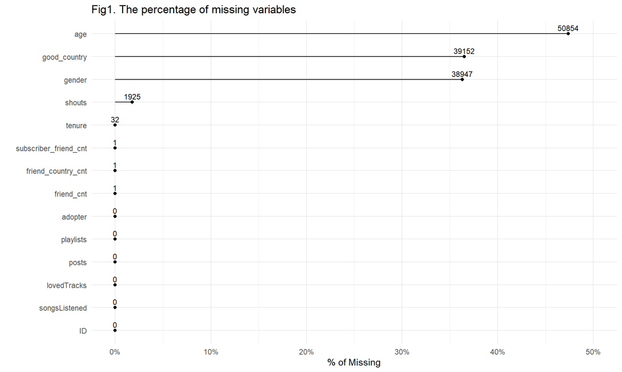

```r
# skimr::skim(dt)

dt_miss <- dt %>%
  select(-c(matches("Pre_"), matches("Post_"),
            matches("avg_")))

dt_miss <- data.frame(
  colnames = colnames(dt_miss),
  tot_cnt = dim(dt_miss)[1],
  missing_cnt = colSums(is.na(dt_miss))) %>%
  mutate(missing_perc = round(missing_cnt/tot_cnt, 3)) %>%
  arrange(missing_cnt) %>%
  mutate(name = factor(colnames, levels = colnames))

dt_miss %>%
  ggplot(aes(name, missing_perc, label = missing_cnt)) +
  geom_segment(aes(x = name, xend = name,
                   y = 0, yend = missing_perc)) +
  geom_point() +
  geom_text(size = 3, vjust = -0.5) +
  labs(x = "", y = "% of Missing",
       title = "Fig1. The percentage of missing variables") +
  scale_y_continuous(labels = scales::percent,
                     limit = c(0, 0.5),
                     breaks = c(0, 0.1, 0.2, 0.3, 0.4, 0.5)) +
  coord_flip()
```

### Create new variables

- age_group:
  - age < 18 : Under18
  - 18 $\le$ age $\le$ 35 : 18-35
  - 35 $\le$ age $\le$ 80 : Over35
  - Null: Unknown

- gender_group
  - 0: Female
  - 1: Male
  - Unknown: NULL

The original `good_country` has 37% missing values. These are replaced with unknown instead of one of the categories.

- good_country_group:
  - 0 = otherwise,
  - 1 = UK/US/Germany,
  - Unknown = NULL

```r
dt2 <- dt %>%
  mutate(gender_gr = ifelse(is.na(gender) == TRUE, "Unknown", ifelse(gender == 1, "Male", "Female")),
         age_gr = case_when(
           age < 18 ~ "Under18",
           age < 35 ~ "18-35",
           age < 80 ~ "Over35",
           TRUE ~ "Unknown") %>%
           factor(level = c("Under18", "18-35","Over35", "Unknown")),
         good_country = case_when(
           good_country == 1 ~ "UK/US/Germany",
           good_country == 0 ~ "Elsewhere",
           TRUE ~ "Unknown"),
         tenure = ifelse(is.na(tenure) == TRUE, 0, tenure),
         shouts = ifelse(is.na(shouts) == TRUE, 0, shouts),
         adopter = as.factor(adopter)) %>%
  mutate_if(is.character, as.factor)

df <- dt2 %>%
  filter(is.na(friend_cnt) == FALSE) %>%
  select(-c(matches("Pre_"), matches("Post_"), matches("avg_"), age, gender))
```

## EDA

correlation within numerical variables.

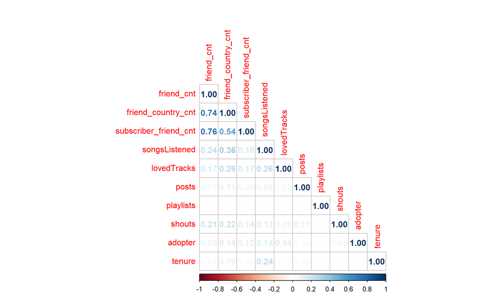

```r
# p_value <- df %>%
#   mutate(adopter = as.numeric(adopter)) %>%
#   select(where(is.numeric)) %>%
#   corrplot::cor.mtest(method='pearson')

df %>%
  mutate(adopter = as.numeric(adopter)) %>%
  select(where(is.numeric)) %>%
  cor() %>%
  corrplot::corrplot(method = "number", type = "lower")
```

```r
  # corrplot::corrplot.mixed(p.mat=p_value[[1]], sig.level=.05,
  #                lower = 'number', upper='pie', tl.cex=.6,
  #                tl.col='black',order='hclust')
```

### Numerical variables

The target variable-`adopter` is highly imbalanced data because its proportion of premium is only 7%. It means that we need to apply the sampling method before applying it to the machine learning method.

```r
prop.table(table(dt2$adopter)) # Highly imbalanced data
```

```
##
##          0          1
## 0.93271769 0.06728231
```

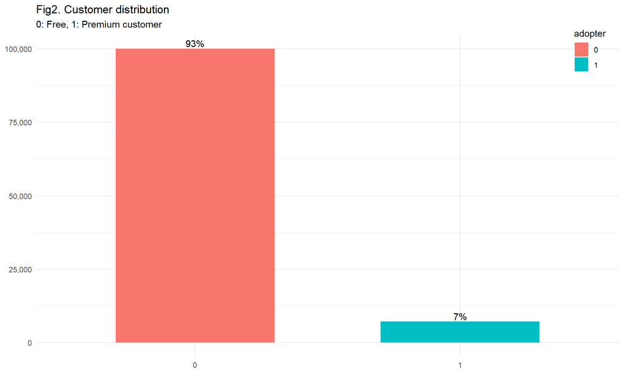

```r
dt2 %>% # adopter(Y)
  group_by(adopter) %>%
  summarise(n = n(),
            prop = n/nrow(.),
            label = scales::percent(prop)) %>%
  ggplot(aes(x = adopter, y = n,label = label)) +
  geom_col(aes(fill = adopter), width = 0.6) +
  geom_text(vjust = -0.25) +
  labs(title = "Fig2. Customer distribution",
       subtitle = "0: Free, 1: Premium customer") +
  scale_y_continuous(labels = scales::comma) +
  theme(axis.title = element_blank(),
        legend.position = c(0.95, 0.95))
```

`adopter` has two categories which are only a Free customer(`0`) and a Premium customer(`1`) so we consider it is a binary.

The below box plots are for checking the differences between Free customers and Premium customers according to the numeric variables. We can see more clear differences when we take out the outliers.

We detect some extreme outliers in the boxplots. In addition, some variables such as `lovedTracks`, `songsListened`, and `subscriber_friend_cnt` have distinct mean differences between the free customer and premium customer. We assume that it would be considered an important variable in the model.

#### friend_count

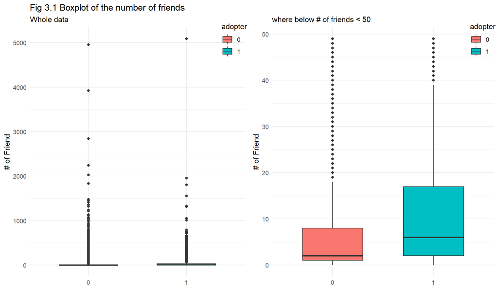

```r
ggpubr::ggarrange(
df %>% # adopter X friend_cnt
  ggplot() +
  geom_boxplot(aes(x = adopter, y = friend_cnt,
                   fill = adopter), width = 0.6) +
  labs(x = "", y = "# of Friend",
    title = "Fig 3.1 Boxplot of the number of friends",
    subtitle = "Whole data") +
  theme(legend.position = c(0.95, 0.95)),

df %>% # adopter X friend_cnt
  filter(friend_cnt < 50) %>%
  ggplot() +
  geom_boxplot(aes(x = adopter, y = friend_cnt,
                   fill = adopter), width = 0.6) +
  labs(x = "", y = "# of Friend",
    title = "",
    subtitle = "where below # of friends < 50") +
  theme(legend.position = c(0.95, 0.95))
)
```

#### friend_country_count

This explains whether the user has a diverse.

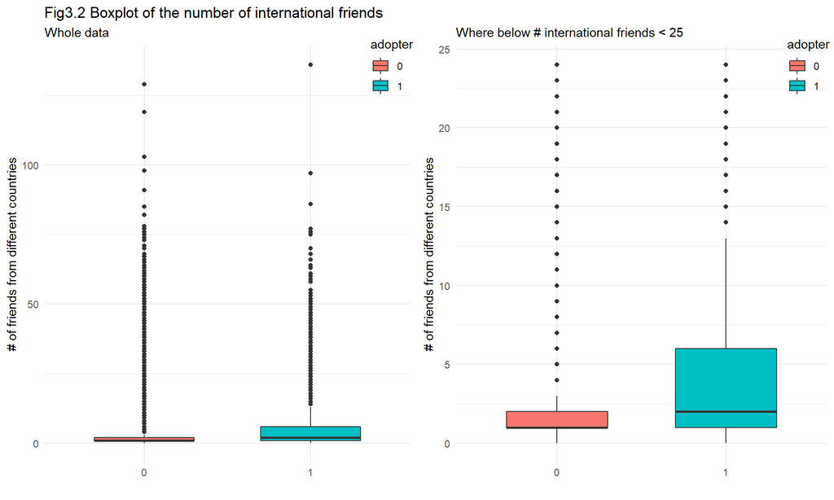

```r
ggpubr::ggarrange(
df %>% # adopter X friend_country_cnt
  ggplot() +
  geom_boxplot(aes(x = adopter, y = friend_country_cnt,
                   fill = adopter), width = 0.6) +
  labs(x = "", y = "# of friends from different countries",
       title = "Fig3.2 Boxplot of the number of international friends",
       subtitle = "Whole data") +
  theme(legend.position = c(0.95, 0.95)),

df %>% # adopter X friend_country_cnt
  filter(friend_country_cnt < 25) %>%
  ggplot() +
  geom_boxplot(aes(x = adopter, y = friend_country_cnt,
                   fill = adopter), width = 0.6) +
  labs(x = "", y = "# of friends from different countries",
       title = "",
       subtitle = "Where below # international friends < 25")+
  theme(legend.position = c(0.95, 0.95)))
```

#### songsListened

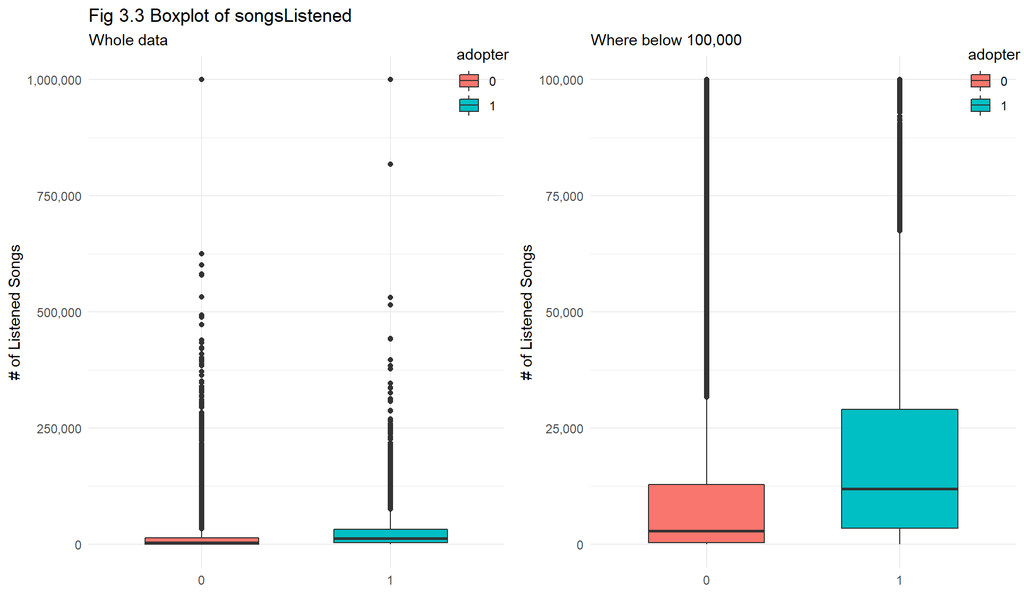

```r
ggpubr::ggarrange(
df %>% # adopter X songsListened
  ggplot() +
  geom_boxplot(aes(x = adopter, y = songsListened,
               fill = adopter), width = 0.6) +
  scale_y_continuous(labels = scales::comma) +
  labs(x = "", y = "# of Listened Songs",
       title = "Fig 3.3 Boxplot of songsListened",
       subtitle = "Whole data") +
  theme(legend.position = c(0.95, 0.95)) ,

df %>% # adopter X songsListened
  filter(songsListened < 100000) %>%
  ggplot() +
  geom_boxplot(aes(x = adopter, y = songsListened,
               fill = adopter), width = 0.6) +
  scale_y_continuous(labels = scales::comma) +
  labs(x = "", y = "# of Listened Songs",
       title = "",
       subtitle = "Where below 100,000") +
  theme(legend.position = c(0.95, 0.95))
)
```

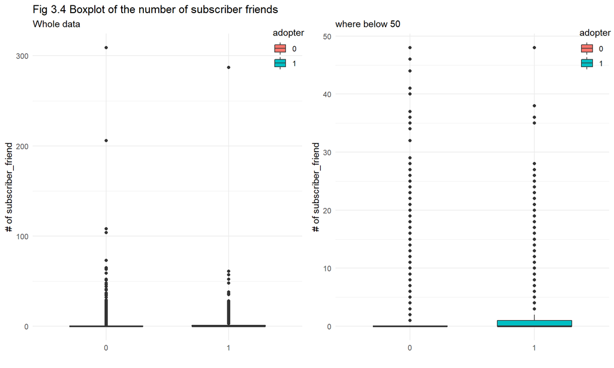

```r
ggpubr::ggarrange(
df %>% # adopter X subscriber_friend_cnt
  ggplot() +
  geom_boxplot(aes(x = adopter, y = subscriber_friend_cnt,
                   fill = adopter), width = 0.6) +
  labs(x = "", y = "# of subscriber_friend",
       title = "Fig 3.4 Boxplot of the number of subscriber friends",
       subtitle = "Whole data") +
  theme(legend.position = c(0.95, 0.95)),

df %>% # adopter X subscriber_friend_cnt
  filter(subscriber_friend_cnt < 50) %>%
  ggplot() +
  geom_boxplot(aes(x = adopter, y = subscriber_friend_cnt,
                   fill = adopter), width = 0.6) +
  labs(x = "", y = "# of subscriber_friend",
       title = "",
       subtitle = "where below 50") +
  theme(legend.position = c(0.95, 0.95))
)
```

#### lovedTracks

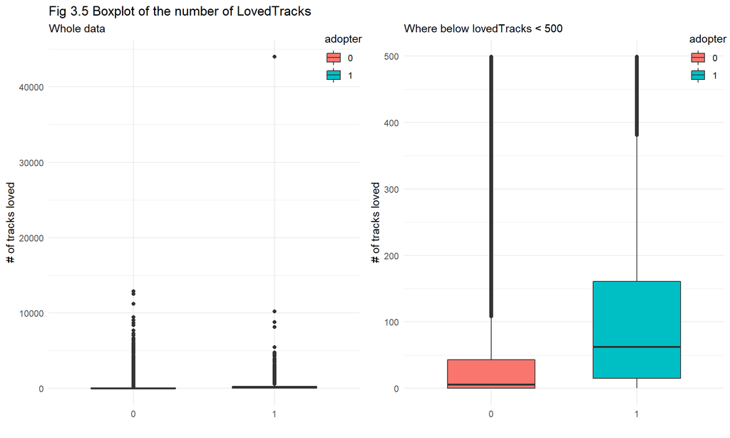

```r
ggpubr::ggarrange(
df %>% # adopter X lovedTracks
  ggplot() +
  geom_boxplot(aes(x = adopter, y = lovedTracks,
                   fill = adopter), width = 0.6) +
  labs(x = "", y = "# of tracks loved",
       title = "Fig 3.5 Boxplot of the number of LovedTracks",
       subtitle = "Whole data") +
  theme(legend.position = c(0.95, 0.95)),

df %>% # adopter X lovedTracks
  filter(lovedTracks < 500) %>%
  ggplot() +
  geom_boxplot(aes(x = adopter, y = lovedTracks,
                   fill = adopter), width = 0.6) +
  labs(x = "", y = "# of tracks loved",
       title = "",
       subtitle = "Where below lovedTracks < 500") +
  theme(legend.position = c(0.95, 0.95))
)
```

#### playlists

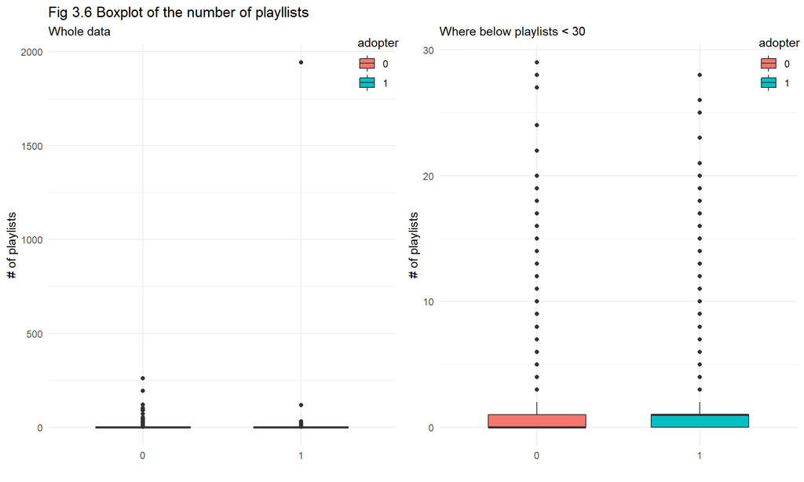

```r
ggpubr::ggarrange(
dt2 %>% # adopter X playlists
  ggplot() +
  geom_boxplot(aes(x = adopter, y = playlists,
                   fill = adopter), width = 0.6) +
  labs(x = "", y = "# of playlists",
       title = "Fig 3.6 Boxplot of the number of playllists",
       subtitle = "Whole data") +
  theme(legend.position = c(0.95, 0.95)),

dt2 %>% # adopter X playlists
  filter(playlists < 30) %>%
  # too many outliers
  ggplot() +
  geom_boxplot(aes(x = adopter, y = playlists,
                   fill = adopter), width = 0.6) +
  labs(x = "", y = "# of playlists",
       title = "",
       subtitle = "Where below playlists < 30") +
  theme(legend.position = c(0.95, 0.95))
)
```

#### shouts

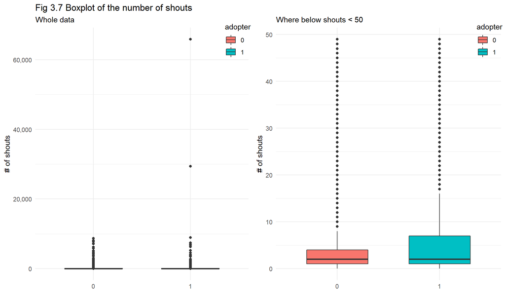

```r
ggpubr::ggarrange(
df %>% # adopter X shouts
  ggplot() +
  geom_boxplot(aes(x = adopter, y = shouts,
                   fill = adopter), width = 0.6) +
  labs(x = "", y = "# of shouts",
       title = "Fig 3.7 Boxplot of the number of shouts",
       subtitle = "Whole data") +
  scale_y_continuous(labels = scales::comma) +
  theme(legend.position = c(0.95, 0.95)),

df %>% # adopter X shouts
  filter(shouts < 50) %>%
  ggplot() +
  geom_boxplot(aes(x = adopter, y = shouts,
                   fill = adopter), width = 0.6) +
  labs(x = "", y = "# of shouts",
       title = "",
       subtitle = "Where below shouts < 50") +
  theme(legend.position = c(0.95, 0.95))
)
```

### Categorical variables

#### age_group

```r
xtabs(~adopter + age_gr, df)
```

```
##        age_gr
## adopter Under18 18-35 Over35 Unknown
##       0    4224 43844   3787   48136
##       1     138  3849    509    2717
```

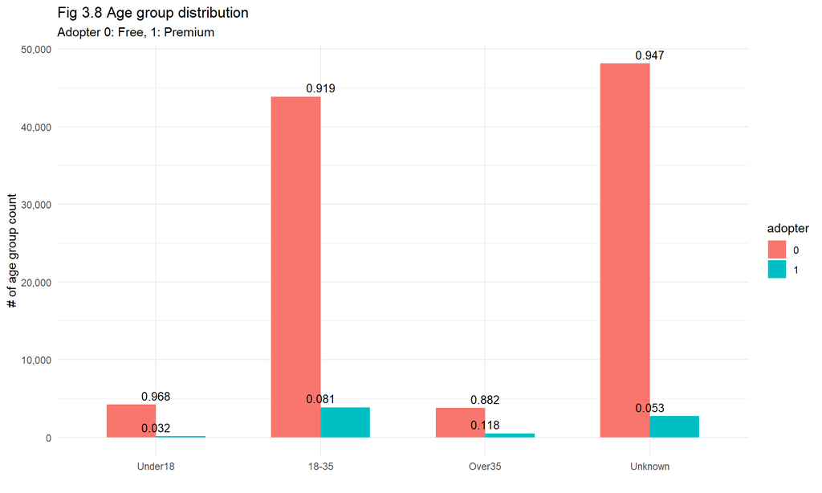

```r
df %>% group_by(age_gr, adopter) %>% tally() %>%
  ungroup() %>% group_by(age_gr) %>%
  mutate(tot = sum(n), perc = round(n/tot, 3)) %>%
  ggplot() +
  geom_col(aes(x = age_gr, y = n, fill = adopter),
           position = "dodge", width = 0.6) +
  geom_text(aes(x = age_gr, y = n, label = perc),
            vjust = -0.5,
            size = 3.5) +
  scale_y_continuous(labels = scales::comma) +
  labs(x = "", y = "# of age group count",
       title = "Fig 3.8 Age group distribution",
       subtitle = "Adopter 0: Free, 1: Premium")
```

#### gender_group

The original male which is renamed as gender has 36% missing. We discovered that it could be defined as three or two groups; male, female, and unknown or whether gender is known or unknown.

```r
xtabs(~ adopter + gender_gr, df)
```

```
##        gender_gr
## adopter Female  Male Unknown
##       0  24206 38735   37050
##       1   1505  3812    1896
```

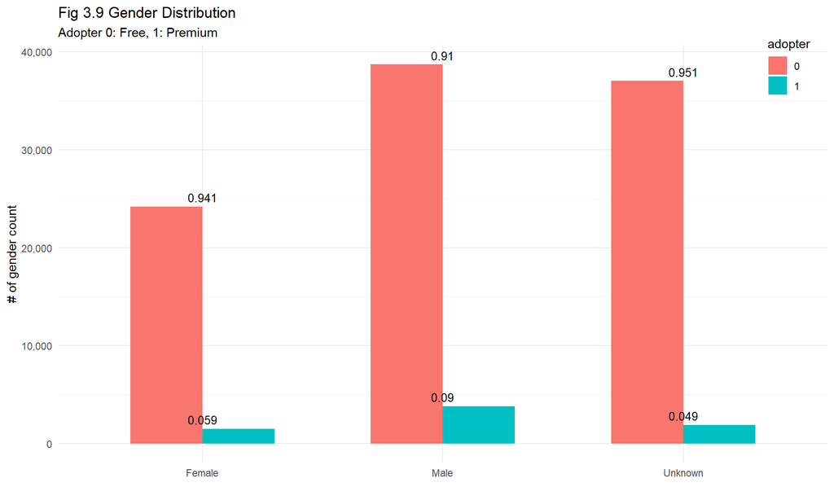

```r
df %>% group_by(gender_gr, adopter) %>% tally() %>%
  ungroup() %>% group_by(gender_gr) %>%
  mutate(tot = sum(n), perc = round(n/tot, 3)) %>%
  ggplot() +
  geom_col(aes(x = gender_gr, y = n, fill = adopter),
           position = "dodge", width = 0.6) +
  geom_text(aes(x = gender_gr, y = n, label = perc),
            position = position_dodge(.9), vjust = -0.5,
            size = 3.5) +
  scale_y_continuous(label = scales::comma) +
  labs(x = "", y = "# of gender count",
       title = "Fig 3.9 Gender Distribution",
       subtitle = "Adopter 0: Free, 1: Premium") +
  theme(legend.position = c(0.95, 0.95))
```

#### good_country_group

```r
xtabs(~ adopter + good_country, df)
```

```
##        good_country
## adopter Elsewhere UK/US/Germany Unknown
##       0     39354         23340   37297
##       1      3668          1691    1854
```

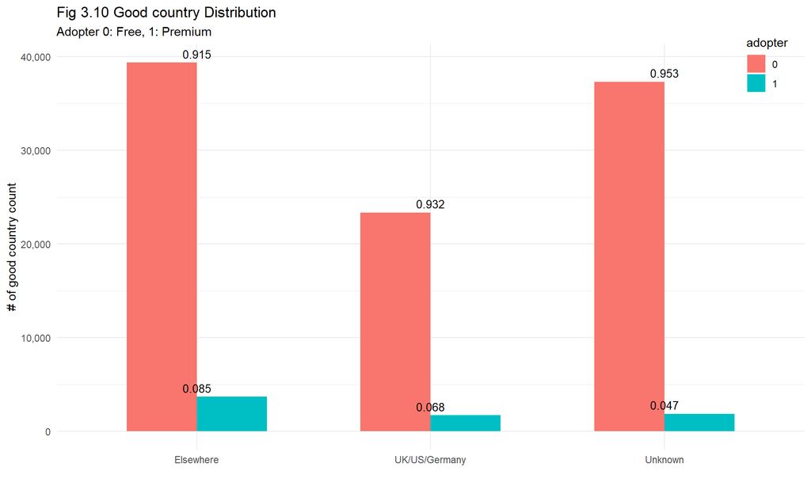

```r
df %>% group_by(good_country, adopter) %>% tally() %>%
  ungroup() %>% group_by(good_country) %>%
  mutate(tot = sum(n), perc = round(n/tot, 3)) %>%
  ggplot() +
  geom_col(aes(x = good_country, y = n, fill = adopter),
           position = "dodge", width = 0.6) +
  geom_text(aes(x = good_country, y = n, label = perc),
            position = position_dodge(.5), vjust = -0.5,
            size = 3.5) +
  scale_y_continuous(label = scales::comma) +
  labs(x = "", y = "# of good country count",
       title = "Fig 3.10 Good country Distribution",
       subtitle = "Adopter 0: Free, 1: Premium") +
  theme(legend.position = c(0.95, 0.95))
```

## Modeling

This is imbalanced data because the ratio of the premium is 7%. Thus, it would be better to compare which sampling methods are appropriate. In addition, we discovered some extreme values through the Exploratory Data Analysis so we would delete these. On the current basis, the total data is 107,205

data is filtered by the below conditions;

- friend_cnt < 50,
- friend_country_cnt < 25,
- songsListened < 100000,
- subscriber_friend_cnt < 50,
- lovedTracks < 500,
- playlists < 30,
- shouts < 50

```r
df2 <- df %>% filter(friend_cnt < 50,
              friend_country_cnt < 25,
              songsListened < 100000,
              subscriber_friend_cnt < 50,
              lovedTracks < 500,
              playlists < 30,
              shouts < 50)
```

### sampling methods

```r
set.seed(2021)

df2_sample <- df2 %>%
  select(-ID) %>%
  rsample::initial_split(., 0.7, strata = adopter)

df2_tr <- df2_sample %>% training()
df2_te <- df2_sample %>% testing()

rf <- ranger::ranger(adopter~., data = df2_tr,
                     num.trees = 100, mtry = 10,
                     importance = "permutation")

over_sample <- ROSE::ovun.sample(adopter~., data = df2_tr,
                                 method = "over")$data
table(over_sample$adopter)
```

```
##
##     0     1
## 63396 63074
```

```r
rfover <- ranger::ranger(adopter~., data = over_sample,
                         num.trees = 100, mtry = 10,
                         importance = "permutation")

under_sample <- ovun.sample(adopter~., data = df2_tr,
                                 method = "under")$data
table(under_sample$adopter)
```

```
##
##    0    1
## 3681 3686
```

```r
rfunder <- ranger::ranger(adopter~., data = under_sample,
                         num.trees = 100, mtry = 10,
                         importance = "permutation")

both_sample <- ovun.sample(adopter~., data = df2_tr,
                           method = "both")$data
table(both_sample$adopter)
```

```
##
##     0     1
## 33508 33574
```

```r
rfboth <- ranger::ranger(adopter~., data = both_sample,
                         num.trees = 100, mtry = 10,
                         importance = "permutation")

sample_metric = function(CM){
  TN =CM[1,1]
  TP =CM[2,2]
  FP =CM[1,2]
  FN =CM[2,1]
  precision =(TP)/(TP+FP) # sensitivity
  recall_score =(FP)/(FP+TN) # specificity

  f1_score=2*((precision*recall_score)/(precision+recall_score))
  accuracy_model  =(TP+TN)/(TP+TN+FP+FN)
  False_positive_rate =(FP)/(FP+TN)
  False_negative_rate =(FN)/(FN+TP)

  x = list(
    sens = round(precision, 5),
    spec = round(recall_score, 5),
    False_Peg = round(False_positive_rate, 5),
    False_Neg = round(False_negative_rate, 5),
    accuracy = round(accuracy_model, 5),
    f1_score = round(f1_score, 5)
  ) %>% as.data.frame()
  return(x)
}
sampling_method = cbind.data.frame(
  method = c("None", "Over", "Under", "Both"),
  metric = rbind(
    sample_metric(rf$confusion.matrix),
    sample_metric(rfover$confusion.matrix),
    sample_metric(rfunder$confusion.matrix),
    sample_metric(rfboth$confusion.matrix)))
sampling_method
```

```
##   method metric.sens metric.spec metric.False_Peg metric.False_Neg
## 1   None     0.29965     0.00317          0.00317          0.97667
## 2   Over     0.98617     0.01394          0.01394          0.00044
## 3  Under     0.68599     0.33116          0.33116          0.27754
## 4   Both     0.97170     0.02916          0.02916          0.00071
##   metric.accuracy metric.f1_score
## 1         0.94334         0.00627
## 2         0.99279         0.02750
## 3         0.69567         0.44668
## 4         0.98508         0.05662
```

Based on `f1_score`, `Under` sampling has the highest value among the sampling technique. Although the accuracy is lower than other sampling methods, it shows a realistic accuracy as a general rule of thumb.

### Random Forest

`Random Forest` is a known technique using decision trees. It could be used for regression and classification. Using this algorithm, we would check the variable importance, probability.

```r
df2_recipe <-
  recipes::recipe(adopter ~ ., data = df2_tr) %>%
  step_dummy(age_gr, gender_gr, good_country) %>%
  step_corr(all_predictors(), -all_outcomes()) %>%
  step_zv(all_numeric()) %>%
  step_normalize(all_numeric(), -all_outcomes()) %>%
  step_downsample(adopter) %>%
  prep(., retain = TRUE)
df2_recipe
```

```
## Data Recipe
##
## Inputs:
##
##       role #variables
##    outcome          1
##  predictor         12
##
## Training data contained 67082 data points and no missing data.
##
## Operations:
##
## Dummy variables from age_gr, gender_gr, good_country [trained]
## Correlation filter removed no terms [trained]
## Zero variance filter removed no terms [trained]
## Centering and scaling for friend_cnt, ... [trained]
## Down-sampling based on adopter [trained]
```

```r
df2_testing <- df2_recipe %>%
  bake(testing(df2_sample))
df2_training <- juice(df2_recipe)

df2_ranger <- rand_forest(#trees = 100, mtry = 10,
                          mode = "classification") %>%
  set_engine("ranger", importance = "permutation") %>%
  fit(adopter ~ ., data = df2_training)
```

#### Scoring

```r
# df2_tr_pred <- df2_ranger %>%
#   predict(df2_training) %>%
#   bind_cols(df2_training)
# xtabs(~ adopter + .pred_class, df2_tr_pred)
# sample_metric(xtabs(~ adopter + .pred_class, df2_tr_pred))


df2_te_pred <- df2_ranger %>%
  predict(df2_testing) %>%
  bind_cols(df2_testing)

xtabs(~ adopter + .pred_class, df2_te_pred)
```

```
##        .pred_class
## adopter     0     1
##       0 18635  8565
##       1   420  1130
```

```r
sample_metric(xtabs(~ adopter + .pred_class, df2_te_pred))
```

```
##      sens    spec False_Peg False_Neg accuracy f1_score
## 1 0.11655 0.31489   0.31489   0.27097  0.68748  0.17014
```

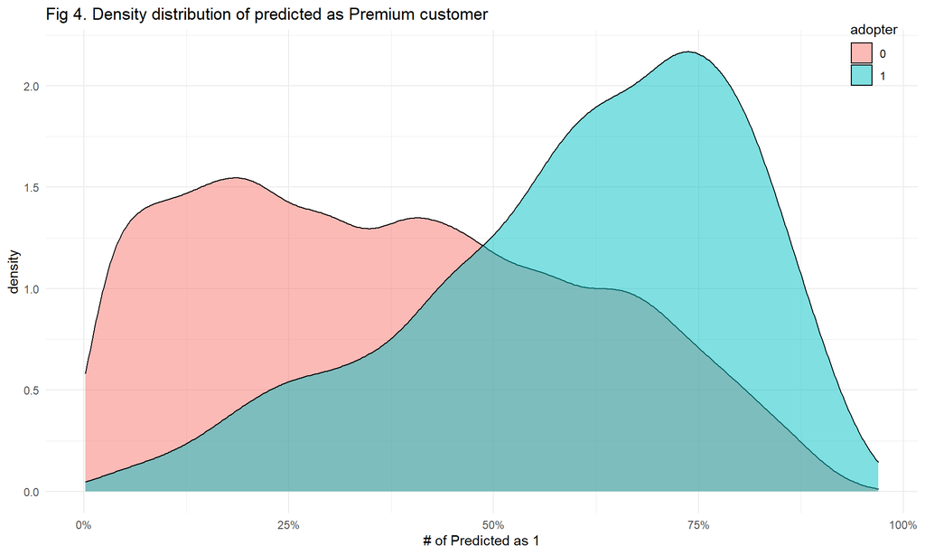

```r
df2_te_probs <- df2_ranger %>%
  predict(df2_testing, type = "prob") %>%
  bind_cols(df2_testing)

df2_te_probs %>%
  ggplot() +
  geom_density(aes(x = .pred_1, fill = adopter),
               alpha = 0.5) +
  scale_x_continuous(labels = scales::percent) +
  labs(x = "# of Predicted as 1",
       title = "Fig 4. Density distribution of predicted as Premium customer") +
  theme(legend.position = c(0.95, 0.95))
```

```r
predict(df2_ranger, df2_testing, type = "prob") %>%
  bind_cols(predict(df2_ranger, df2_testing)) %>%
  bind_cols(select(df2_testing, adopter)) %>%
  tail(5)
```

```
## # A tibble: 5 x 4
##   .pred_0 .pred_1 .pred_class adopter
##     <dbl>   <dbl> <fct>       <fct>
## 1   0.350   0.650 1           1
## 2   0.408   0.592 1           1
## 3   0.617   0.383 0           1
## 4   0.524   0.476 0           1
## 5   0.680   0.320 0           1
```

#### variable importance

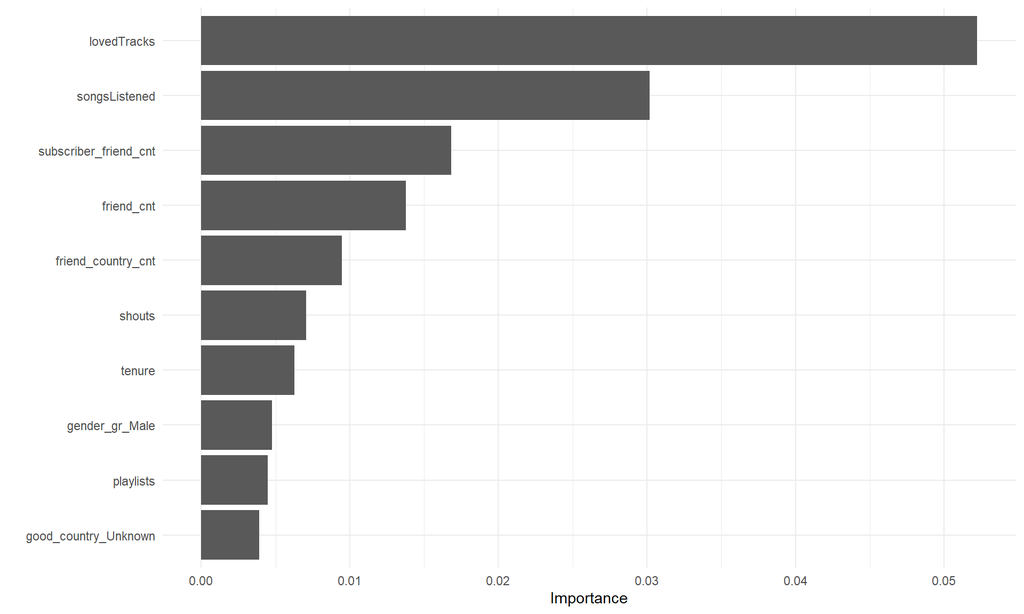

```r
require(vip)
vip(df2_ranger)
```

## Conclusion + further possible analysis

Based on our predefined question, we can conclude as below;

- In the random forest model, the variable with the most impact is `lovedTracks`, `songsListened`, and `subscriber_friend_cnt`. This supports evidence of the assumption based on the Exploratory Data Analysis. We could interpret that the user’s activity(listening to songs, the number of friends) is the main key to the premium customer. On the other hand, the demographic variables(gender, age, good_country) have relatively less important value in the random forest model.
- Use the score to customer target segmentation whether the model predicts as `0(Free customer)` or `1(Premium customer)`. The default threshold is 0.5, however, it could be changed depending on the business purpose.

Further possibility:

- Model tuning could find the best parameter of the random forest model
- If there are more premium customers, the imbalanced problem possibly could be removed.
- Improving how to collect the data for preventing high missing variables
- Outliers can be treated as one of the segments when defining VIP customers.
- If there are other variables(monetary, visiting time), RFM analysis would be possible to consider for customer segmentation.
- If there is a post_adoptor(whether the customer would stay after x months later), churn analysis would be possible with the premise of other variables remaining equal.